# 1. 기술통계학

# 2. 추론통계학

# 3. 베이즈통계학

# 표본추출방법

- 단순랜덤
- 계통추출
- 층화추출
- 군집추출

- R에서는 sample 함수를 이용해서 표본 추출이 가능
  - sample(모집단, 표본수, 복원/비복원여부)

```r
sample(x=1:10, 5, replace = T) #복원추출
```

```
## [1]  1  8 10  3 10
```

```r
menu <- c('연어','삼겹살','곱창','참치','양꼬치')
sample(menu, 1 , replace = F) #비복원추출
```

```
## [1] "양꼬치"
```

# 자료의 종류

- 질적자료
  - 명목자료
  - 순서자료
  - 구간자료
  - 비율자료
- 양적자료
  - 이산형
  - 연속형

```
# 타이타닉 자료에서 성별, 승선위치별, 승선등급별
# 승객 비율을 조사해서 출력
```

```r
setwd('C:/Users/tjoeun/Desktop/R/day03/titanic')
titanic <- read.csv('titanic.csv')
head(titanic)
```

```
##   pclass survived                                            name    sex
## 1      1        1                   Allen, Miss. Elisabeth Walton female
## 2      1        1                  Allison, Master. Hudson Trevor   male
## 3      1        0                    Allison, Miss. Helen Loraine female
## 4      1        0            Allison, Mr. Hudson Joshua Creighton   male
## 5      1        0 Allison, Mrs. Hudson J C (Bessie Waldo Daniels) female
## 6      1        1                             Anderson, Mr. Harry   male
##       age sibsp parch ticket     fare   cabin embarked
## 1 29.0000     0     0  24160 211.3375      B5        S
## 2  0.9167     1     2 113781 151.5500 C22 C26        S
## 3  2.0000     1     2 113781 151.5500 C22 C26        S
## 4 30.0000     1     2 113781 151.5500 C22 C26        S
## 5 25.0000     1     2 113781 151.5500 C22 C26        S
## 6 48.0000     0     0  19952  26.5500     E12        S
```

```r
summary(titanic)
```

```
##      pclass         survived                                name
##  Min.   :1.000   Min.   :0.000   Connolly, Miss. Kate         :   2
##  1st Qu.:2.000   1st Qu.:0.000   Kelly, Mr. James             :   2
##  Median :3.000   Median :0.000                                :   1
##  Mean   :2.295   Mean   :0.382   Abbing, Mr. Anthony          :   1
##  3rd Qu.:3.000   3rd Qu.:1.000   Abbott, Master. Eugene Joseph:   1
##  Max.   :3.000   Max.   :1.000   Abbott, Mr. Rossmore Edward  :   1
##  NA's   :1       NA's   :1       (Other)                      :1302
##      sex           age              sibsp            parch
##        :  1   Min.   : 0.1667   Min.   :0.0000   Min.   :0.000
##  female:466   1st Qu.:21.0000   1st Qu.:0.0000   1st Qu.:0.000
##  male  :843   Median :28.0000   Median :0.0000   Median :0.000
##               Mean   :29.8811   Mean   :0.4989   Mean   :0.385
##               3rd Qu.:39.0000   3rd Qu.:1.0000   3rd Qu.:0.000
##               Max.   :80.0000   Max.   :8.0000   Max.   :9.000
##               NA's   :264       NA's   :1        NA's   :1
##       ticket          fare                     cabin      embarked
##  CA. 2343:  11   Min.   :  0.000                  :1015    :  3
##  1601    :   8   1st Qu.:  7.896   C23 C25 C27    :   6   C:270
##  CA 2144 :   8   Median : 14.454   B57 B59 B63 B66:   5   Q:123
##  3101295 :   7   Mean   : 33.295   G6             :   5   S:914
##  347077  :   7   3rd Qu.: 31.275   B96 B98        :   4
##  347082  :   7   Max.   :512.329   C22 C26        :   4
##  (Other) :1262   NA's   :2         (Other)        : 271
```

```r
#성별 승객 현황

frq_gender <- table(titanic$sex)
print(frq_gender)
```

```
##
##        female   male
##      1    466    843
```

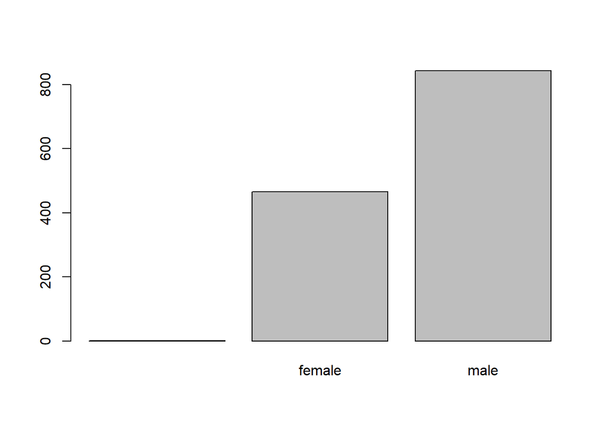

```r
barplot(frq_gender)
```

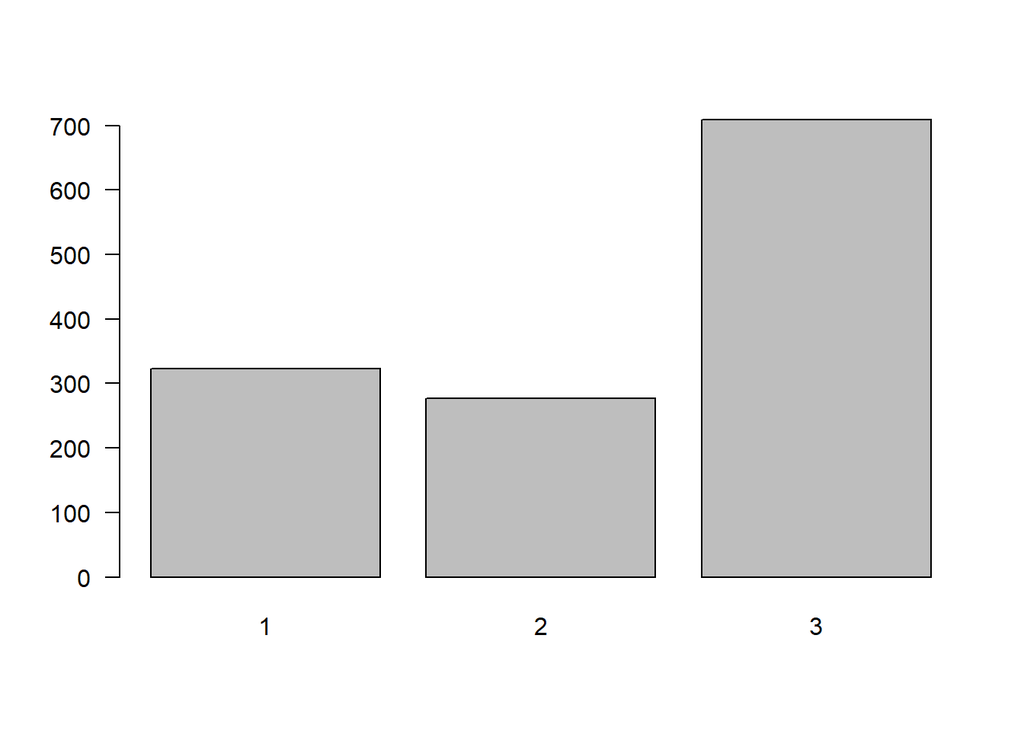

```r
#승선권 등급별 승객 현황
frq_pcls <- table(titanic$pclass)
barplot(frq_pcls, las = 1)
```

```r
#승선위치별 승객 현황
frq_embk <- table(titanic$embarked)
frq_embk
```

```
##
##       C   Q   S
##   3 270 123 914
```

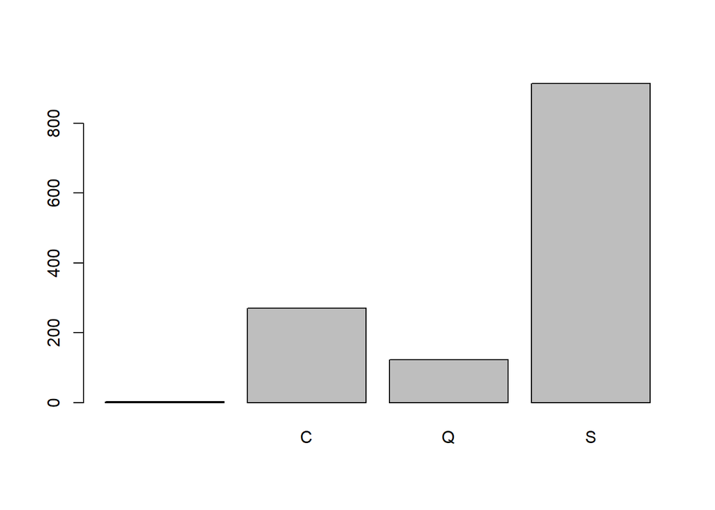

```r
barplot(frq_embk)
```

```r
age <- titanic$age[!is.na(titanic$age)]
ages <- as.character(age)

df_age <- data.frame(age, ages, stringsAsFactors = F)

head(df_age, 10)
```

```
##        age   ages
## 1  29.0000     29
## 2   0.9167 0.9167
## 3   2.0000      2
## 4  30.0000     30
## 5  25.0000     25
## 6  48.0000     48
## 7  63.0000     63
## 8  39.0000     39
## 9  53.0000     53
## 10 71.0000     71
```

```r
df_age <- within(df_age, {
  ages[age <= 1 ] <- '~01'
ages[age >= 2 & age < 5 ] <- '~05'
ages[age >= 5 & age < 13] <- '~13'
ages[age >= 13 & age < 19 ] <- '~19'
ages[age >= 19 & age < 30 ] <- '~29'
ages[age >= 30 & age < 40 ] <- '~39'
ages[age >= 40 & age < 50 ] <- '~49'
ages[age >= 50 & age < 60 ] <- '~59'
ages[age >= 60 & age < 70 ] <- '~69'
ages[age >= 70 & age < 80 ] <- '~79'
ages[age >= 80 ] <- '~80'
})

head(df_age$ages, 10)
```

```
##  [1] "~29" "~01" "~05" "~39" "~29" "~49" "~69" "~39" "~59" "~79"
```

```r
#분류된 결과에 대한 빈도표 작성하고 시각화

frq_ages <- table(df_age$ages)
frq_ages
```

```
##
## ~01 ~05 ~13 ~19 ~29 ~39 ~49 ~59 ~69 ~79 ~80
##  22  29  43 102 373 232 135  70  32   7   1
```

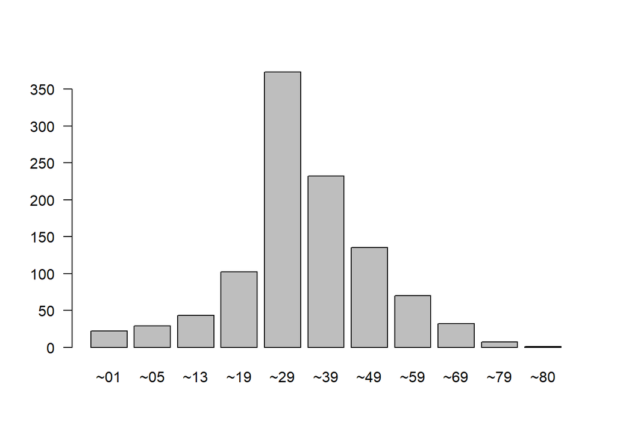

```r
#빈도표를 막대그래프 시각화
barplot(frq_ages, las=1)
```

# 통계 중요용어

- 모집단 +$ U $, $ N $
- 표본 +$ S $, $ n $

# 중심화 경향

- 평균값
- 중앙값
- 최빈값

# 분산화 경향

- 범위
- 사분위수
- 분산
- 표준편차

# 대표값

### 평균 : 중심척도의 대표적인 통계값

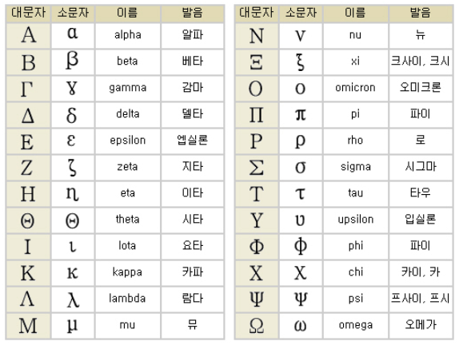

### 모평균

> > $$\mu = \dfrac{1}{N} \sum_{n=1}^N x_i$$

### 표본평균

- $ x $

```r
# 평균 : mean(x, na.rm=F)
# x : 평균을 구할 대상
# 결측치 포함여부
x = c(1,2,3,4,5,6,7,8,9,10)

mean(x)
```

```
## [1] 5.5
```

```r
# 조선 왕들의 평균수명?
kings <- c(73,62,45,53,38,16,51,28,37,30,56,30,33,56,
           66,54,40,33,59,36,82,48,44,22,32,67,52)

mean(kings)
```

```
## [1] 46.03704
```

### 중앙값

- $ M_e $

```r
# 중앙값 : median(x, na.rm=F)
a <- c(1:9)
b <- c(1:10)

median(a)
```

```
## [1] 5
```

```r
median(b)
```

```
## [1] 5.5
```

```r
# 중앙값 계산

x <- c(12,7,3,4.2,18,2,54,-21,8,-5)

sort(x)
```

```
##  [1] -21.0  -5.0   2.0   3.0   4.2   7.0   8.0  12.0  18.0  54.0
```

```r
median(x)
```

```
## [1] 5.6
```

### 최빈값

- $ M_o $
- R에서는 최빈값을 구하는 함수가 제공되지 않음
- table 함수와 which.max함수를 이용해서 구하도록 함

```r
# 최빈값
# 빈도표 작성 : table(x)
# 최대빈도 요소 위치값 조사 : which.max(x)
# 빈도표의 컬럼명 조사 : names(x)

x <- c(2,1,2,3,1,2,3,4,1,5,5,3,2,3)
sort(x)
```

```
##  [1] 1 1 1 2 2 2 2 3 3 3 3 4 5 5
```

```r
table(x)
```

```
## x
## 1 2 3 4 5
## 3 4 4 1 2
```

```r
frqx <- table(x)
frqx
```

```
## x
## 1 2 3 4 5
## 3 4 4 1 2
```

```r
maxidx <- which.max(frqx)
maxidx
```

```
## 2
## 2
```

```r
names(frqx[maxidx])
```

```
## [1] "2"
```

```r
# 위 예에서는 최빈값이 2개인데 1개만 나옴
```

```r
# 최빈값 구하는 함수 : get_mode
getmode <- function(x){}
getmode
```

```
## function(x){}
```

```r
# 평균이 동일한 자료들

a <- c(1,2,3,4,5,5,5,6,7,8,8,9,9,9,9)
b <- c(4,5,5,5,6,6,6,6,6,6,6,7,7,7,8)
mean(a)
```

```
## [1] 6
```

```r
mean(b)
```

```
## [1] 6
```

```r
median(a)
```

```
## [1] 6
```

```r
median(b)
```

```
## [1] 6
```

```r
# 두 자료 모두 평균은 동일하지만
# 자료의 구성은 다름
```

### 범위

- $ R $

```r
# 범위 : range(x)

range(a)
```

```
## [1] 1 9
```

```r
range(b)
```

```
## [1] 4 8
```

```r
max(a) - min(a)
```

```
## [1] 8
```

```r
# 조선 왕들의 평균수명 범위?
kings <- c(73,62,45,53,38,16,51,28,37,30,56,30,33,56,
           66,54,40,33,59,36,82,48,44,22,32,67,52)


range(kings)
```

```
## [1] 16 82
```

```r
max(kings)-min(kings)
```

```
## [1] 66
```

### 분산

- 모분산 : $\sigma^2$
- 표본분산 : $S^2$

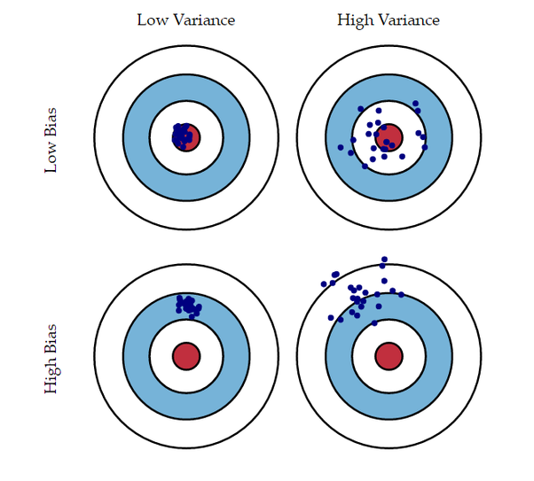

```r
# 조선 왕들의 평균수명 범위?
kings <- c(73,62,45,53,38,16,51,28,37,30,56,30,33,56,
           66,54,40,33,59,36,82,48,44,22,32,67,52)

var(kings)
```

```
## [1] 261.5755
```

```r
# 결과값이 이상함
```

```r
my.var <- function(x){
  m <- mean(x) # 평균계산
  return(sum((x - m)^2)/(length(x)-1)) # 표본분산


}

# retrun (sum((x - m)^2)/(length(x))) # 모분산


my.var(kings)
```

```
## [1] 261.5755
```

```r
# 어떤 가푸치노 판매점들의 5일동안
# 오후 4~5시 사이의 판매량 데이터를 보고
# 어느 지점이 판매를 잘 하였는지 파악

ga <- c(20,40,50,60,80)
na <- c(20,45,50,55,80)



mean(ga)
```

```
## [1] 50
```

```r
mean(na)
```

```
## [1] 50
```

```r
summary(ga)
```

```
##    Min. 1st Qu.  Median    Mean 3rd Qu.    Max.
##      20      40      50      50      60      80
```

```r
summary(na)
```

```
##    Min. 1st Qu.  Median    Mean 3rd Qu.    Max.
##      20      45      50      50      55      80
```

```r
# 중심화경향으로 기술통계 실시  -> 가늠 할 수 없음



coffee.var <- function(x){
  m <- mean(x)
  return(sum((x - m)^2)/(length(x)-1)) # 표본분산


}

coffee.var(ga)
```

```
## [1] 500
```

```r
coffee.var(na)
```

```
## [1] 462.5
```

```r
var(ga)
```

```
## [1] 500
```

```r
var(na)
```

```
## [1] 462.5
```

```r
# 각 데이터의 위치(분산)척도로 두 집단의 차이를 알아 봄
# 나 집단이 분산이 적음으로 좀 더 괜찮은 판매추이를 보임(더 일정함)
```

### 표준편차

- 분산을 구하기 위해 편차($x_i - \bar x$)의 제곱합을 구함
- 편차의 제곱합 덕에 값이 너무 커짐
- 따라서, 분산값에 제곱근(루트)을 취함으로써 측정값과 같은 단위로 변환 가능
- $S$

```r
# 분산 : sd(x)
# 조선왈들의 수명 표준편차

var(kings)
```

```
## [1] 261.5755
```

```r
sd(kings)
```

```
## [1] 16.1733
```

```r
# 회계사원들의 웝급과 사무수습사원들의 월급비교
# 수습사원 평균월급은 3550, 표준편차는 250이다
acc <- c(3536,3173,3448,3121,3622)

summary(acc)
```

```
##    Min. 1st Qu.  Median    Mean 3rd Qu.    Max.
##    3121    3173    3448    3380    3536    3622
```

```r
sd(acc)
```

```
## [1] 222.179
```

# 대표적인 위치척도를 이용한 기술통계

# 관측치를 여러부분으로 나눠 각 값들의 위치를 결정

# 사분위수를 구하는 방법은 데이터의 유형과 방식에 따라

9가지가 존재 * $Q_1, Q_2, Q_3, Q_4$

### 사분위수 구하는 방법

- 먼저, 중앙값을 구함 : 2사분위수
- 중앙값을 기준을 왼쪽방향의 1사분위수를 구함
- 중앙값을 기준을 오른쪽방향의 3사분위수를 구함

```r
# 표본이 다음과 같을 때 Q1, Q2 , Q3 구하기
nums <- c(1,3,4,7,10,11,20,22,25,30,31)

median(nums)
```

```
## [1] 11
```

```r
fivenum(nums)
```

```
## [1]  1.0  5.5 11.0 23.5 31.0
```

```r
quantile(nums, type = 1) # 위치 기반
```

```
##   0%  25%  50%  75% 100%
##    1    4   11   25   31
```

```r
quantile(nums, type = 6) # 값 기반
```

```
##   0%  25%  50%  75% 100%
##    1    4   11   25   31
```

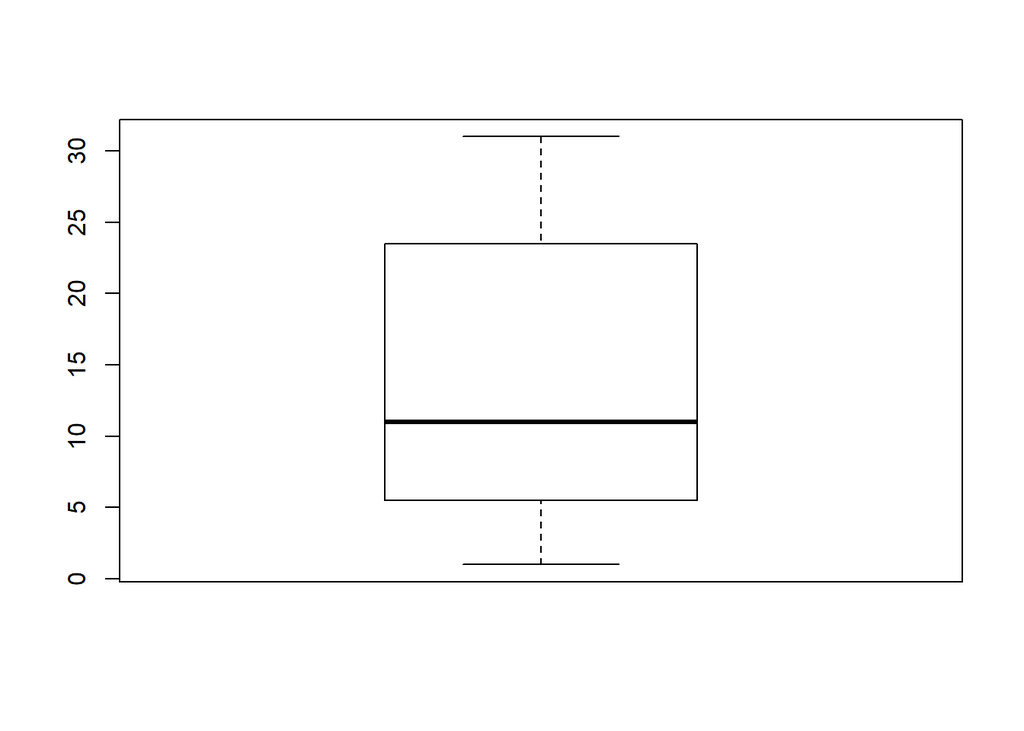

```r
boxplot(nums)
```

```r
# 사분위수 : quantile(x, type)
# 위치 기반 사분위수 : fivenum(x)
# 비연속형 수치 (위치기준) : type 1~3 (1추천)
# 연속형 수치 (값기준): type 4~9 (6추천)

x <- c(1,2,3,4,10,50,100)
quantile(x)
```

```
##    0%   25%   50%   75%  100%
##   1.0   2.5   4.0  30.0 100.0
```

```r
fivenum(x)
```

```
## [1]   1.0   2.5   4.0  30.0 100.0
```

```r
quantile(x , type =1)
```

```
##   0%  25%  50%  75% 100%
##    1    2    4   50  100
```

```r
quantile(x , type =2)
```

```
##   0%  25%  50%  75% 100%
##    1    2    4   50  100
```

```r
quantile(x , type =3)
```

```
##   0%  25%  50%  75% 100%
##    1    2    4   10  100
```

```r
quantile(x , type =4)
```

```
##     0%    25%    50%    75%   100%
##   1.00   1.75   3.50  20.00 100.00
```

```r
quantile(x , type =5)
```

```
##     0%    25%    50%    75%   100%
##   1.00   2.25   4.00  40.00 100.00
```

```r
quantile(x , type =6)
```

```
##   0%  25%  50%  75% 100%
##    1    2    4   50  100
```

```r
quantile(x , type =7)
```

```
##    0%   25%   50%   75%  100%
##   1.0   2.5   4.0  30.0 100.0
```

```r
quantile(x , type =8)
```

```
##         0%        25%        50%        75%       100%
##   1.000000   2.166667   4.000000  43.333333 100.000000
```

```r
quantile(x , type =9)
```

```
##       0%      25%      50%      75%     100%
##   1.0000   2.1875   4.0000  42.5000 100.0000
```

```r
numf <- c(1,2,2,4,4,6,7,8,9,10,12,12)

summary(numf)
```

```
##    Min. 1st Qu.  Median    Mean 3rd Qu.    Max.
##   1.000   3.500   6.500   6.417   9.250  12.000
```

```r
quantile(numf, type = 1)
```

```
##   0%  25%  50%  75% 100%
##    1    2    6    9   12
```

```r
quantile(numf, type = 6)
```

```
##    0%   25%   50%   75%  100%
##  1.00  2.50  6.50  9.75 12.00
```

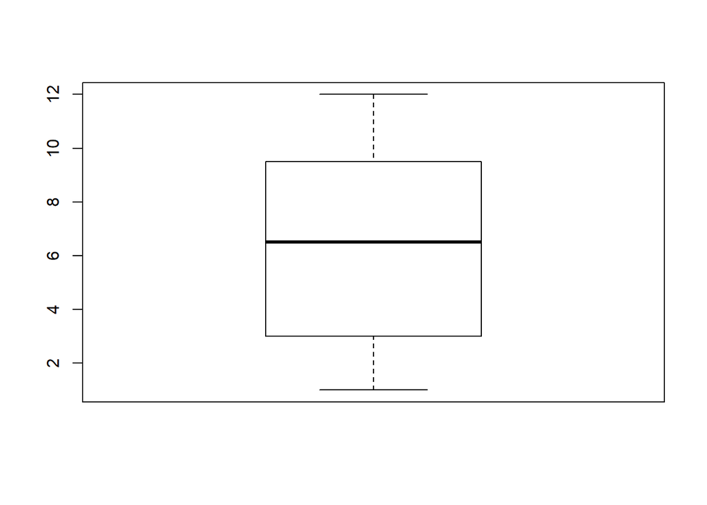

```r
boxplot(numf)
```

### 사분위수 활용방법

- fivenum : 상자수염그래프와 같이 사용
- quantile : 일반적인 사분위수

# 비대칭도

- 중심치 경향과 분포 경향을 통해 표본의 특성과 산포 정도를 파악 가능
- 분포가 좌우대칭/완만정도를 파악하기 어려움
- 표본의 도수분포에서 평균에 대한 비대칭방향과 정도를 어느정도 알 수 있음

```r
# 80명의 학생데이터의 분포에 대한 시각화
# 먼저, 도수분포표를 작성

heights <- read.csv('height.csv')
summary(heights)
```

```
##      height
##  Min.   :143.0
##  1st Qu.:154.0
##  Median :157.5
##  Mean   :157.6
##  3rd Qu.:161.2
##  Max.   :169.0
```

```r
# 구간파악 : 최대/최소 파악

min <- min(heights)
max <- max(heights)


# min # 143 -> 140 (내림)
# max # 169 -> 170 (올림)

min <- as.integer(min/10)*10
max <- as.integer(max/10)*10+10


min
```

```
## [1] 140
```

```r
max
```

```
## [1] 170
```

```r
# 구간별 범위 지정

bins <- seq(min,max,5 )
```

```r
# 계급값 : 각 계급을 대표하는 값, 계급의 중앙 값
# 140,145,150,155,160,165,170

mid <- ((bins[2] - bins[1]) / 2 )
mdbins <- bins + mid
mdbins
```

```
## [1] 142.5 147.5 152.5 157.5 162.5 167.5 172.5
```

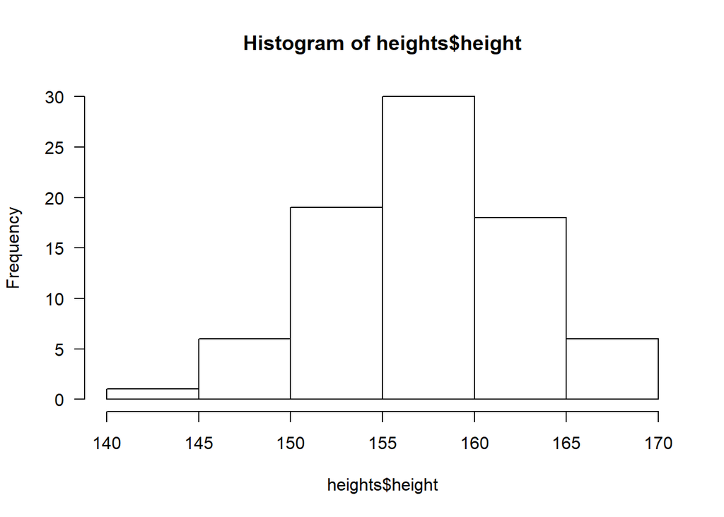

```r
# 상대도수 구하기 : 전체도수 / 전체빈도수


total <- length(heights$height)
h <- hist(heights$height, las=1)
```

```r
relfrq <-h$counts / total
relfrq
```

```
## [1] 0.0125 0.0750 0.2375 0.3750 0.2250 0.0750
```

```r
sum(relfrq)
```

```
## [1] 1
```

```r
# 누적도수 : 각 구간별 도수 누적합
# 누적합 : cumsum(x)
h$counts
```

```
## [1]  1  6 19 30 18  6
```

```r
csfrq <- cumsum(h$counts)
csfrq
```

```
## [1]  1  7 26 56 74 80
```

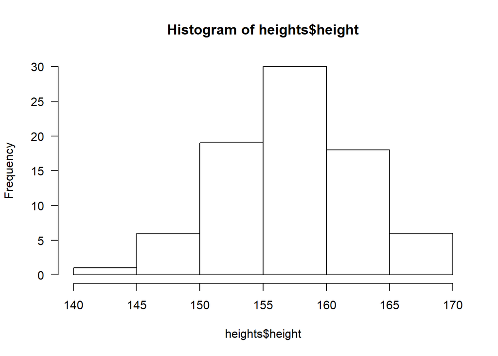

```r
# 히스토그램, 계급값, 상대도수, 누적도수 시각화
hist(heights$height, las=1)
```

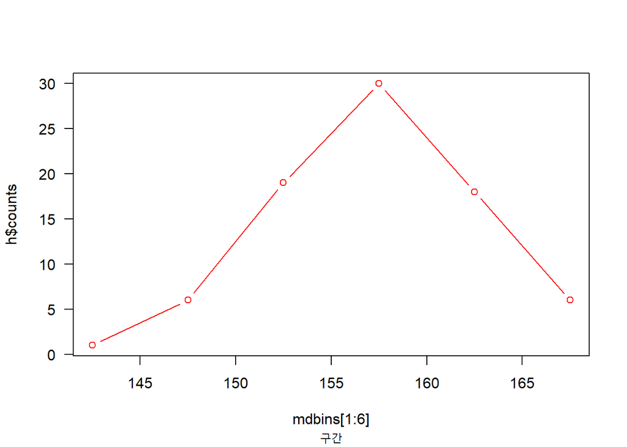

```r
plot(mdbins[1:6], h$counts, type = 'b' , col = 'red' , las=1, sub = '구간')
```

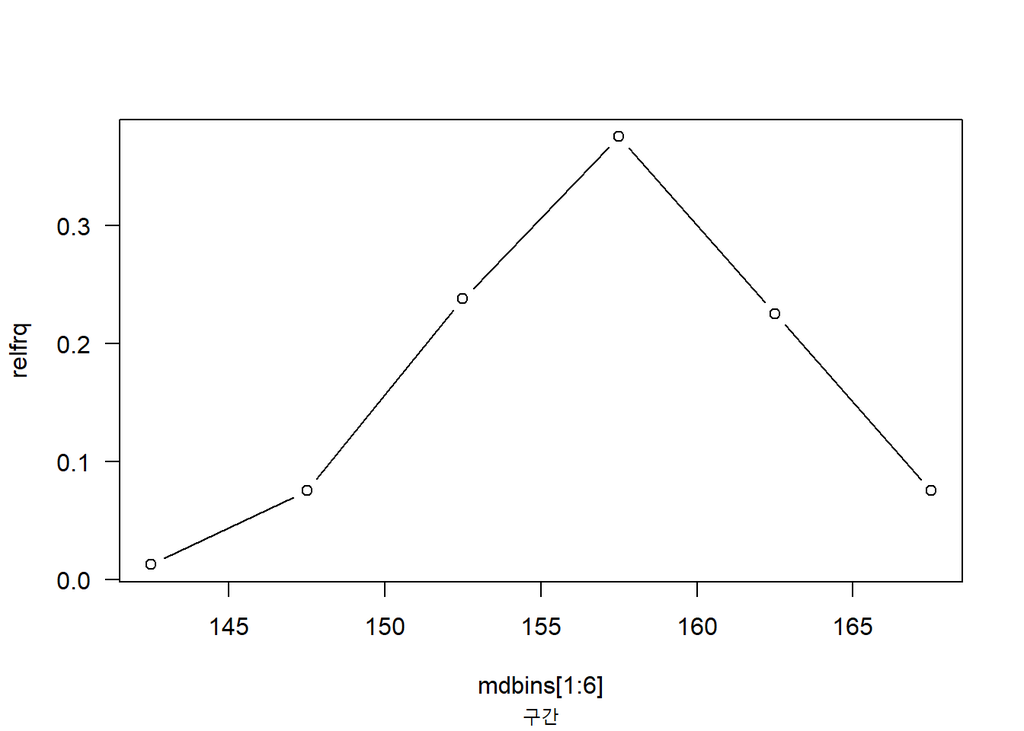

```r
plot(mdbins[1:6], relfrq, type = 'b' , col = 'black' , las=1, sub = '구간')
```

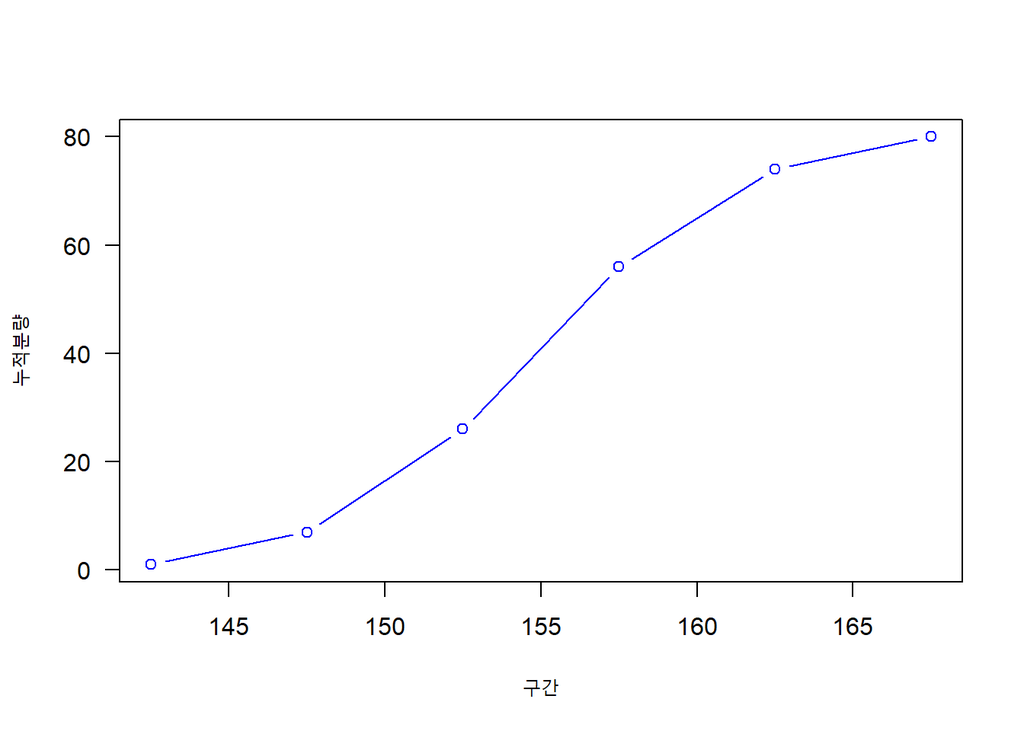

```r
plot(mdbins[1:6], csfrq, type = 'b' , col = 'blue' , las=1, xlab = '구간'
     ,ylab = '누적분량')
```

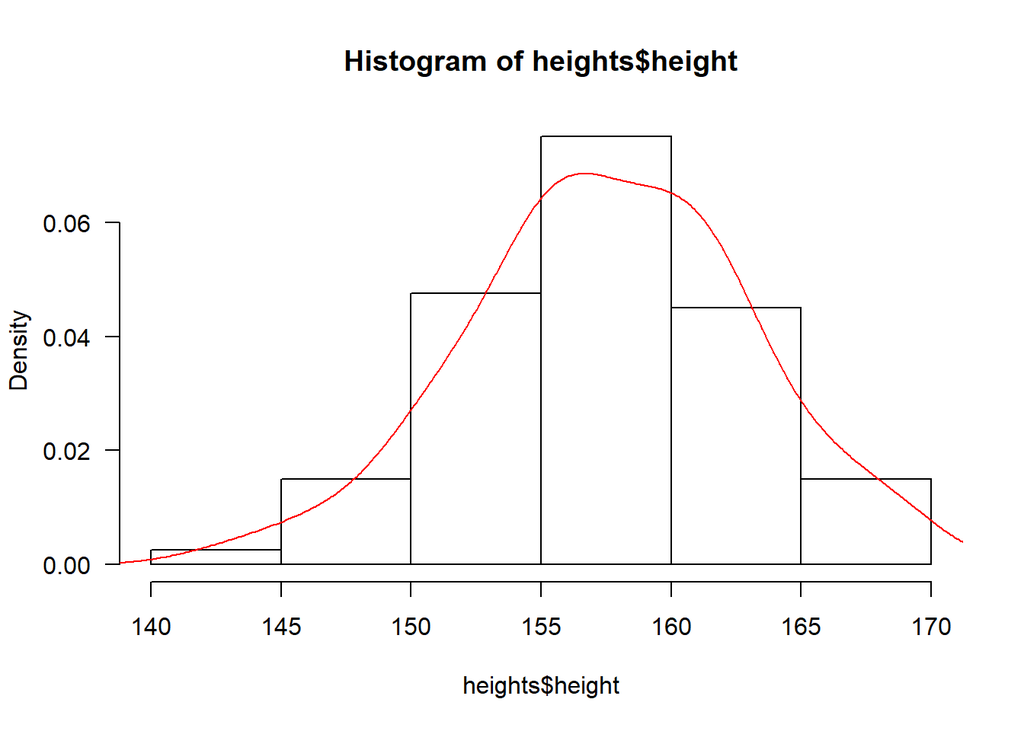

```r
hist(heights$height, freq = F, las = 1)
lines(density(heights$height), col = 'red') # 확률밀도곡선
```

### 왜도

- 분포곡선이 좌측이나 우측으로 어느정도 쏠렸는지 나타냄
- 왜도가 0보다 크면 왼쪽으로 쏠리는 분포로 나타나짐
- 즉, 오른쪽으로 꼬리가 긴 분포로 나타남

### 첨도

- 분포곡선의 봉우리가 어느정도로 뾰족한지 나타냄
- 첨도가 3보다 크면 폭이 좁고 봉우리가 높은 분포를 나타냄
- 간혹 프로그램에 따라 0을 기준으로 측정하는 경우도 있음

```r
# R에서는 psych 패키지의 skew와 kurtosi 함수를 이용
# 왜도 : skew(x)
# 첨도 : kurtosi(x)
```

install.packages(‘moments’) library(moments)

```r
# skewness(x)
# kurtosis(x)
```

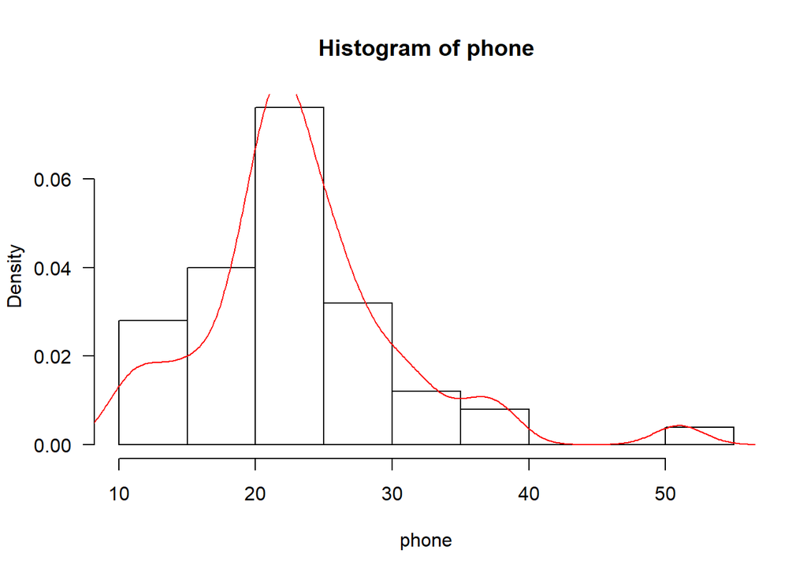

```r
# 청소년 핸드폰 사용시간에 대한 히스토그램과
# KDE를 작성

phone <- c(10,37,22,32,18,15,15,18,22,15,20,25,38,28,
         25,30,20,22,18,22,22,12,22,26,22,32,22,23,
         20,23,23,20,25,51,20,25,26,22,26,28,28,20,
         23,30,12,22,35,11,20,25)


hist(phone, freq = F, las = 1)
lines(density(phone), col = 'red')
```

```r
# skewness(phone)
# kurtosis(phone)
```

### 확률밀도추정

- kernal density estimation
- 관측된 데이터들의 분포로부터 원래 변수의 확률분포특성을 추정
- 즉, 해당변수에서 관측된 몇 가지 데이터로 부터 변수가 가질수 있는 모든값들에 대한 밀도(확률)를 추정하는 것

```r
# ex) 어느 회사의 주당이익자료임
# (0.09,0.13,0.41,0.51,1.12,1.20,1.49,3.18,3.50,6.36,7.83,8.92,10.13,12.99,16.40)
# 평균,사분위값, 표준편차, 왜도, 첨도는?

eps <- c(0.09,0.13,0.41,0.51,1.12,1.20,1.49,3.18,3.50,6.36,7.83,8.92,10.13,12.99,16.40)

#대표값 경향
mean(eps)
```

```
## [1] 4.950667
```

```r
median(eps)
```

```
## [1] 3.18
```

```r
getmode(eps)
```

[output not shown]

```r
#분산경향
var(eps)
```

```
## [1] 27.26682
```

```r
sqrt(eps)
```

```
##  [1] 0.3000000 0.3605551 0.6403124 0.7141428 1.0583005 1.0954451 1.2206556
##  [8] 1.7832555 1.8708287 2.5219040 2.7982137 2.9866369 3.1827661 3.6041643
## [15] 4.0496913
```

```r
quantile(eps, type = 6)
```

```
##    0%   25%   50%   75%  100%
##  0.09  0.51  3.18  8.92 16.40
```

```r
#왜도와 첨도
# skewness(eps)
# kurtosis(eps)
```

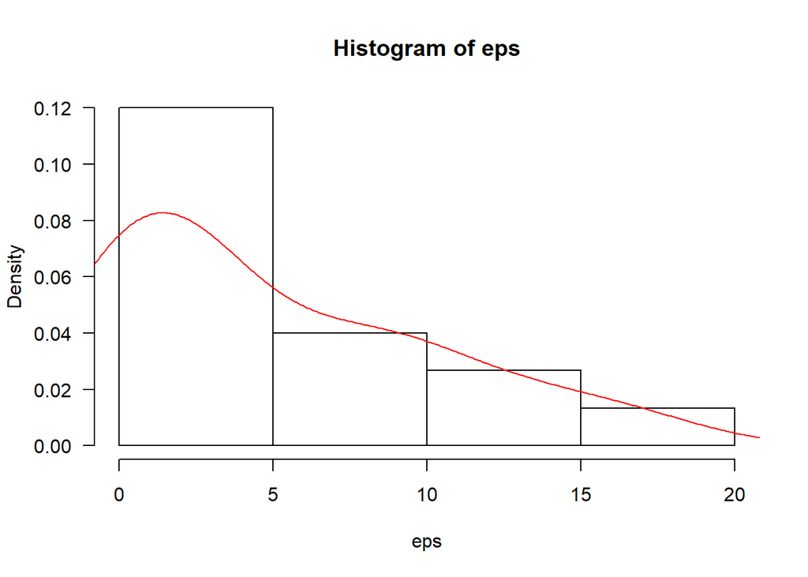

```r
# 확률뷴포 시각화
hist(eps, freq = F, las = 1)
lines(density(eps), col = 'red')
```

```r
# 최빈값 구하는 함수 : get_mode

getmode <- function(x){
  ux <- unique(x)
  tab <- tabulate(match(x, ux))
  ux[tab == max(tab)]


}
```